# Statistical Inference for Election Polling

Oct 24, 2018

First, we load a few R packages

```r
library(tidyverse)
```

# Motivation

In 2012, Nate Silver [declared](http://fivethirtyeight.blogs.nytimes.com/fivethirtyeights-2012-forecast/?_r=0) that Barack Obama had a 91% chance of winning the election and he “appears poised for a decisive electoral victory”.

[figure not shown]

[output not shown]

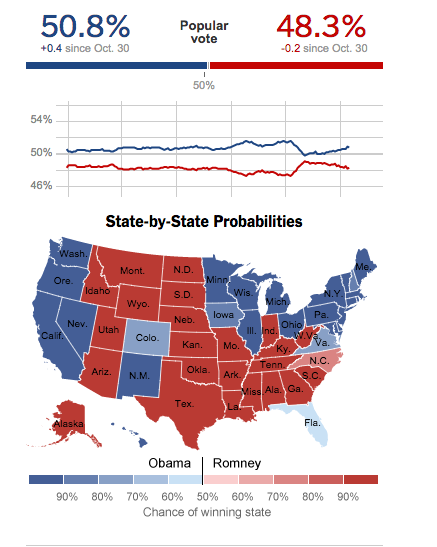

Several pundits were not happy. Here is what Joe Scarborough had to say:

> Anybody that thinks that this race is anything but a tossup right now is such an ideologue, they should be kept away from typewriters, computers, laptops and microphones for the next 10 days, because they’re jokes.

Let’s explore this. We have seen how to use the API for theHuffington Post US Opinion Polling data, which provides US opinion poll data on various political races and other non-political opinion polls.

There is an R package called [`pollstR`](https://cran.r-project.org/web/packages/pollstR/index.html) which provides an easy user interface.

So if we wanted to look at the polls data right before the election (on and after Nov 4, 2012), we could use the `pollster_charts_polls()` function which needs a `slug` argument.

We will use this [poll data](http://elections.huffingtonpost.com/pollster/2012-general-election-romney-vs-obama). Inside the url, the end of it is `2012-general-election-romney-vs-obama`, which is the slug that we use below.

```
## # A tibble: 6 x 15
##   Obama Romney Undecided Other poll_slug        survey_house    start_date
##   <dbl>  <dbl>     <dbl> <dbl> <chr>            <chr>           <date>
## 1    47     47         6    NA politico-gwu-ba… Politico/GWU/B… 2012-11-04
## 2    49     47         3    NA yougov-economis… YouGov/Economi… 2012-11-03
## 3    48     48         4    NA gravis-marketin… Gravis Marketi… 2012-11-03
## 4    50     49        NA     1 ibd-tipp-16679   IBD/TIPP        2012-11-03
## 5    48     49        NA    NA rasmussen-16677  Rasmussen       2012-11-03
## 6    47     47         6    NA jz-analytics-ne… JZ Analytics/N… 2012-11-03
## # ... with 8 more variables: end_date <date>, question_text <chr>,
## #   sample_subpopulation <chr>, observations <int>, margin_of_error <dbl>,
## #   mode <chr>, partisanship <chr>, partisan_affiliation <chr>
```

Next, we can calculate the difference between the proportion of individuals voting for Obama and Romney:

```r
polls <- race2012$content %>%
  select(Obama, Romney, margin_of_error, observations,
         start_date, end_date, partisan_affiliation) %>%
  mutate(diff = Obama - Romney,
         margin_of_error=ifelse(is.na(margin_of_error),0,margin_of_error)) %>%
  rename(n=observations) %>%
  arrange(diff)
head(polls)
```

```
## # A tibble: 6 x 8
##   Obama Romney margin_of_error     n start_date end_date
##   <dbl>  <dbl>           <dbl> <int> <date>     <date>
## 1    45     51             2    2700 2012-10-15 2012-10-21
## 2    42     48             0    1500 2012-03-08 2012-03-10
## 3    46     51             2    2700 2012-10-22 2012-10-28
## 4    44     49             3.5   757 2012-10-04 2012-10-09
## 5    44     49             3    1500 2012-07-24 2012-07-26
## 6    43     48             3    1500 2012-06-19 2012-06-21
## # ... with 2 more variables: partisan_affiliation <chr>, diff <dbl>
```

We can visualize the difference and an upper bound and lower bound of uncertainty for each poll:

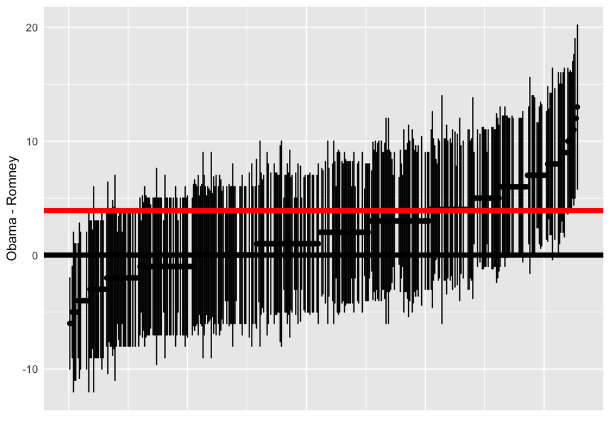

```r
polls %>%
  ggplot( aes(seq_along(diff), Obama-Romney,
              min=diff-2*margin_of_error,
              max=diff+2*margin_of_error)) +
  geom_point() + geom_errorbar() + xlab("") +
  theme(axis.ticks = element_blank(),
        axis.text.x = element_blank()) +
  geom_hline(yintercept = 0, color=1, size=2) +
  geom_hline(yintercept = 3.9, color=2, size=2)
```

The red line represents the true difference (3.9%) between the proportion of people who voted for Obama vs Romney.

Not only did Nate Silver correctly predict that Obama would win, but he also predicted the outcome of all 50 states and DC correctly. Here, we will explain how *poll aggregators*, such as Fivethirtyeight, use statistics and data science to make these predictions.

Specifically, they use probability, statistical inference and modeling. In this lecture we will talk about the first two and the next lecture will focus on the third.

First let’s talk about the data themselves (opinion polls), what it means to have variability between different polls, what a *margin of error* means, and an brief introduction to confidence intervals.

## Data

Opinion polls are commonly used during elections to describe the opinions held by a specific population on a topic of interest. Instead of asking for the opinions of the entire population (impractable and costly), we typically can ask a random sample of people their opinions and try to infer the opinions of the entire population from the random sample.

In statistics, we describe this idea as *statistical inference* and we can use this theory to describe things such as which candidate is likely to win an election, job approval or support of a proposed law or amendement. Opinion polls can also be useful for determining how and where to invest money to increase voter registration or voting efforts.

There are new aggregation sites, such as [Real Clear Politics](http://www.realclearpolitics.com) that aggregate and publish poll results. We will be using it in this and the next lecture and you will use it in your homework assignment, where you will be predicting the outcome of the 2018 Senate Midterm Elections.

It is important to note that forecasting elections is a complicated process. Also, for example, presidential elections are not determined by the popular vote, but we still use the popular vote here to illustrate our example.

In our poll data example, we see that the estimated difference between Obama and Romney (or the *spread*) varies across the different pollsters, but hovers around the actual difference of 3.9%. There is also something called *margin of error* that is reported (also known as MoE sometimes).

Let’s explore this type of data by generating our own imaginary election with 1 million voters (population) of which proportion $p$ are republicans and $1-p$ are democrats. To keep it interesting we will keep generate $p$ at random and not peek.

```r
n <- 10^6 ## number of voters
set.seed(1) ## so we all get the same answer
## pick a number between 0.45 and 0.55 (don't peek!!!!!):
p <- sample(seq(0.45,0.55,0.001),1)
x <- rep(c("R","D"), n*c(p, 1-p))
x <- sample(x) ## not necessary, but shuffle them
```

The population is now fixed. There is a true proportion $p$, but we don’t know it.

On election day we will do the following to decide who wins (don’t ruin the fun by doing it now!):

(DON’T RUN THIS CODE CHUNK IF YOU WANT TO BE SURPRISED)

```r
prop.table(table(x)) # expressed as fractions
```

Pollsters try to *estimate* $p$, but asking 1 million people is actually unnecessary so instead, they take a poll. To do this they take a random sample. They pick $N$ random voter phone numbers, call, and ask. Assuming everybody answers and every voter has a phone, we can mimic a random sample of 25 people with:

```r
poll <- sample(x, 25, replace = TRUE)
poll
```

```
##  [1] "D" "D" "D" "R" "R" "R" "R" "R" "R" "R" "R" "D" "R" "D" "D" "D" "R"
## [18] "D" "R" "D" "R" "R" "D" "D" "D"
```

The pollster then looks at the proportion of republicans in the sample and uses this information to predict $p$. In statistics, we say try to *estimate* $p$.

```r
prop.table(table(poll))
```

```
## poll
##    D    R
## 0.48 0.52
```

Who is predicted to win? Do you think this is a good *estimate* of $p$? We will see how powerful statistics is at informing us about exactly how good it is.

**Notation**: We use lower case $x$ for the population of all voters and capital letters $X$ for the random sample.

# Really quick overview of statistical inference

## Variability between polls

We can repeat the above process multiple times by taking a new random sample of size $N=25$ people to poll individuals if they will vote for a democrat or republican and we see that the observed number varies:

```r
X <- sample(x, 25, replace = TRUE)
sum(X=="R")
```

```
## [1] 14
```

```r
X <- sample(x, 25, replace = TRUE)
sum(X=="R")
```

```
## [1] 15
```

```r
X <- sample(x, 25, replace = TRUE)
sum(X=="R")
```

```
## [1] 11
```

Note how the observed number varies. We refer to this as *random* or *chance* variation. How does this random variable relate to our quantity of interest $p$? Statistical theory has a lot to teach about this and is the main tool used by pollsters and poll aggregators.

## Random sampling

Let’s turn the republicans into 1s and democrats into 0s and model this process like drawing a random sample of beads from a jar and calculating the number of red (or blue) beads.

```r
x <- as.numeric(x=="R")
X <- sample(x, 25, replace = TRUE)
sum(X)
```

```
## [1] 10
```

Because we have the true proportion $p$ (but hidden from us), we can do this a bit quicker by simply using:

```r
X <- sample(c(1,0), 25, replace = TRUE, prob=c(p,1-p))
sum(X)
```

```
## [1] 11
```

## The Expected Value and Standard Error

Using the sampling model described above, we can calculate the *expected value* of the random variable and the *standard error*, which gives us an idea of how the size of the variation around the expected value.

**Recall**: We know from the Central Limit Theorem that if $X \sim Binom(N,p)$ and $\hat{p} = X/N$, the observed proportion of successes, then for sufficiently large $n$, the sampling distirbution of $\hat{p}$, which is our *estimate* of $p$, is approximately normal with mean $p$ and standard deviation $\sqrt{p(1-p)/N}$. Simiarly the sampling distribution of $X$ is approximately normal with mean $Np$ and standard deviation $\sqrt{Np(1-p)}$.

Let $X$ be the number of republicans in our random sample of size $N=25$. Then, the expected value of the proportion of individuals voting for a republican in our sample is

$$\mbox{E}(X/25) = p$$
and the standard error is

$$\mbox{SE}(X/25) = \sqrt{p (1-p) / 25}$$

which implies that $X/25$ will be $p$ plus some chance error. The standard error gives us an idea how large the error is.

By making $N$ larger we can make our standard error smaller. The *Law of Large Numbers* tells us that the bigger $N$ the closer the sample average gets to the average of the population which is the quantity we want to estimate.

So our best guess for $p$ is the observed proportion

```r
X <- sample(c(1,0), 25, replace = TRUE, prob=c(p,1-p))
p_hat <- mean(X)

cat("Our estimate of the percent of republicans is", p_hat,
    "plus or minus", round( sqrt(p_hat*(1-p_hat)/25), 3))
```

```
## Our estimate of the percent of republicans is 0.44 plus or minus 0.099
```

Which is not terribly useful.

However, now we know that we can be more precise by taking a larger poll.

For example, if $p=0.5$, how large should the poll be to have a standard error of 2% or less?

$$\sqrt{0.5(1-0.5)/N} = \sqrt{0.25/N} = 0.02$$
implies
$$N = 0.25/0.02^2 = 625$$

We can take a poll with sample size $N=625$ and report expected value and standard error similar to before:

```r
N <- 625
X <- sample(x, N, replace = TRUE)
p_hat <- mean(X)
cat("Now our estimate of the percent of republicans is",p_hat,
    "plus or minus", round( sqrt(p_hat*(1-p_hat)/N), 2))
```

```
## Now our estimate of the percent of republicans is 0.4976 plus or minus 0.02
```

## Probability Distribution for Random Variables

The plus or minus statements above are not very precise. Is it possible to say more? Can we, for example, compute the probability that $\hat{p}$ is within 2% of the actual $p$? It turns out that we can.

There are two main approaches to do this:

1. Using Monte Carlo simulations
2. Using Central Limit Theorem for normal approximations

### Using Monte Carlo simulations

Repeat the exercise of taking a poll of 625 likely voters, 10,000 times. Without peaking at $p$ study the distribution of $\hat{p}-p$. Have we seen this distribution before?

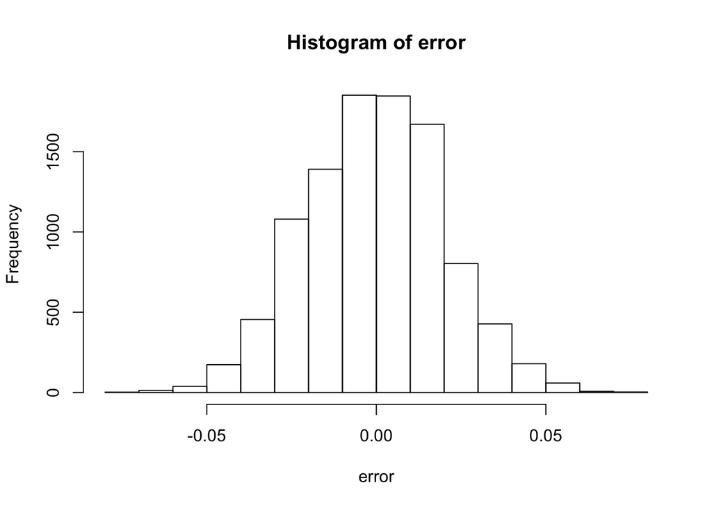

```r
N <- 625
B <- 10^4
error <- replicate(B,{
  X <- sample(x, N, replace = TRUE)
  mean(X)-p
})
hist(error)
```

The distribution above is the *probability distribution* of our random variable. Knowing this distribution will be extremely helpful because we can, for example, report the probability that our error is smaller or larger than 0.02:

```r
mean(abs(error) > 0.02)
```

```
## [1] 0.3239
```

### Using Central Limit Theorem

Using the Monte Carlo simulations (i.e. conducting 10,000 polls), we can see that the probability distribution of $\hat{p}$ is very well approximated with the normal distribution.

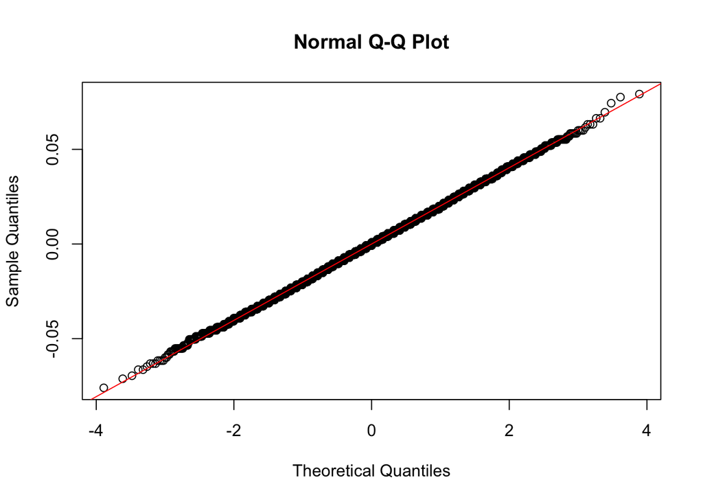

```r
qqnorm(error)
qqline(error,col=2)
```

From the CLT, we also know $\hat{p}$ follows a normal distribution with expected value $p$ and standard error approximately equal to $\sqrt{\hat{p} (1-\hat{p})}/\sqrt{N}$.

This implies that the following random variable $Z$, which is equal to

$$Z = \sqrt{N}\frac{ \hat{p} - p}{\sqrt{\hat{p} (1-\hat{p})}}$$

is approximately normal with expected 0 and standard deviation 1.

The fact that the `error` distribution is centered at 0 confirms that the expected value of $\hat{p}$ is $p$.

The observed standard deviation of the errors is

```r
sqrt(mean((error)^2))
```

```
## [1] 0.020167
```

and matches the theoretical standard error (0.02)

```r
sqrt(p*(1-p)/N)
```

```
## [1] 0.01997695
```

And recall, how often was our error smaller or larger than 0.02?

```r
mean(abs(error) > 0.02)
```

```
## [1] 0.3239
```

Interstingly, we could have predicted that 32% of `error`s were larger than 0.02 using the normal approximation.

Let’s formally define what we mean by *margin of error*.

## Margin of error

Consider
$$\delta = 0.02$$

If we want to know, what’s the probability that the `error` ($\hat{p}-p$) is within $\delta$:

$$\mbox{Pr}( - \delta < \mid p - \hat{p} \mid < \delta)$$
We can use the fact that
$$Z = \sqrt{N}\frac{ \hat{p} - p}{\sqrt{\hat{p} (1-\hat{p})}} \sim N(0,1)$$
and re-write the above probability like this:

$$\mbox{Pr}( | Z | < \sqrt{N} \delta/\sqrt{p(1-p)})$$

Because $Z$ is approximately standard normal this probability is approximately

```r
a = sqrt(N)*.02/sqrt(p_hat*(1-p_hat))
a
```

```
## [1] 1.000012
```

```r
pnorm(a)-pnorm(-a)
```

```
## [1] 0.6826951
```

So we can ask, what proportion of the normal curve is **more** than 1 SD away from the population average?

```r
## compare
mean(abs(error) > 0.02)
```

```
## [1] 0.3239
```

```r
## to
a = sqrt(N)*.02/sqrt(p_hat*(1-p_hat))
pnorm(-a) + (1-pnorm(a))
```

```
## [1] 0.3173049
```

Because conducting 10,000 polls is practically impossible, we can just use the mathematical theory to estimate is $\hat{p}$ and there is 32% chance that our `error` ($\hat{p} - p$) is larger than 2%.

## Confidence Intervals

If we create intervals that miss the target 32% of the time, we will not be considered good forecasters. We can always make less bold predictions, such as “the percent of republicans will be between 0% and 100%” but that will not help our reputation either. Can we find a better balance?

Because there is chance variation, it is impossible to hit the target 100% of time unless we state the obvious “between 0% and 100%”. So let’s compromise a bit. If we hit the target 95% of the time, chances are we will be considered good forecasters. Can we use the theory above to construct such interval?

Yes, using the CLT, we know

$$\hat{p} - z_{1-\alpha} \sqrt{\hat{p} (1-\hat{p})} / \sqrt{N} \leq p \leq \hat{p} + z_{1-\alpha} \sqrt{\hat{p} (1-\hat{p})} / \sqrt{N}$$
or

```r
p_hat + c(-1,1)*qnorm(0.975)*sqrt(p_hat*(1-p_hat))/sqrt(N)
```

```
## [1] 0.4584012 0.5367988
```

This interval has a 95% chance of *covering* the true $p$

Did we actually make a correct prediction? It’s election night and we we will find out

```r
ci <- p_hat + c(-1,1)*qnorm(0.975)*sqrt(p_hat*(1-p_hat))/sqrt(N)
p
```

```
## [1] 0.476
```

```r
ci[1] <= p & ci[2] >= p
```

```
## [1] TRUE
```

### Using Monte Carlo simulations

Note that Nate Silver stated that Obama had a 90% chance of winning. Was this a confidence interval?

The description we have given up to know says nothing about the probability of winnings. In fact, the statement does not even make sense because $p$ is fixed. It is not random. We should not make probability statements.

In other courses, you will learn about Bayesian statistics, where it makes sense to make data-based statements such as “Obama has a 90% chance of winning”.

Here we clarify how we interpret margins of error and confidence intervals.

The 95% confidence interval

```r
p_hat + c(-1,1)*qnorm(0.975)*sqrt(p_hat*(1-p_hat))/sqrt(N)
```

```
## [1] 0.4584012 0.5367988
```

is random because `p_hat` is random.

Let’s use a Monte Carlo simulation to see this with $B=100$ simulations:

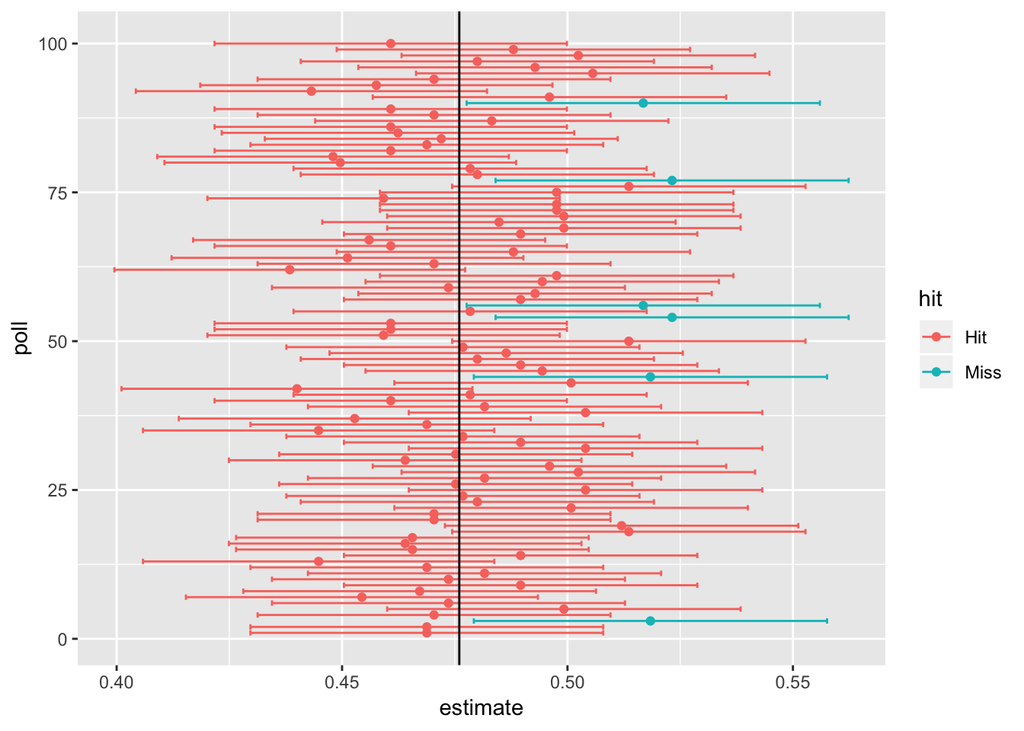

```r
library(dplyr)
library(ggplot2)
N <- 625
B <- 100
tab  <- replicate(B,{
  X <- sample(x, N, replace = TRUE)
  p_hat <- mean(X)
  ci <- p_hat + c(-1,1)*qnorm(0.975)*sqrt(p_hat*(1-p_hat))/sqrt(N)
  hit <- (ci[1] <= p) & (ci[2] >= p)
  c(p_hat,ci,hit)
})

tab <- data.frame(poll=1:ncol(tab), t(tab))
names(tab)<-c("poll","estimate","low","high","hit")
tab <- mutate(tab, hit=ifelse(hit, "Hit","Miss") )
ggplot(tab, aes(poll,estimate,ymin=low,ymax=high,col=hit)) +
  geom_point() + geom_errorbar() +
  coord_flip() + geom_hline(yintercept = p)
```

Notice how the interval is different after each poll: it’s random.

The 95% relates to the probability that this random interval falls on top of $p$, not that $p<.50$ or whatever other statements related to the probability of winning. In the figure above, that shows the interval for 100 polls, you can see that interval fall on $p$ about 95% of the time.

What percent of confidence intervals with margins of error of 0.035 would correctly predict the election?

We can define $\delta = 0.035$ and use the CLT theory like before:

```r
a = sqrt(N)*.035/sqrt(p_hat*(1-p_hat))
pnorm(a)-pnorm(-a)
```

```
## [1] 0.9198852
```

This a 92% confidence interval. Which is not bad, but it’s not the 95% we set out for.

Alternatively, we can check with a Monte Carlo simulation.

```r
N <- 625
B <- 10^5
success  <- replicate(B,{
  X <- sample(x, N, replace = TRUE)
  p_hat <- mean(X)
  ci <- p_hat + c(-0.035,0.035)
  ci[1] <= p  & ci[2] >= p
})
mean(success)
```

```
## [1] 0.92281
```